# Bellabeat Case Study Notebook

# 1. ASK

### Purpose

The purpose of this case study is to showcase my use of R by doing nearly all stages of the process within the coding system. This is a case study recieved through Google as an optional part of the Data Analytics certificate program. The prompt asks analysts to act as a junior analyst and hypothetically assist Bellabeat in adjusting their marketing strategy through the use of Fitbit data. The job was to look for trends within the data.

Fitbit data was retrieved from [here](https://www.kaggle.com/datasets/arashnic/fitbit)

### Business Question

1. What are some trends in smart device usage?
2. How could these trends apply to Bellabeat customers?
3. How could these trends help influence Bellabeat marketing strategy?

### Stakeholders

The stakeholders were provided for the analyst to understand who would be recieving this information.

- Urška Sršen: Bellabeat’s cofounder and Chief Creative Officer.
- Sando Mur: Mathematician and Bellabeat’s cofounder; key member of the Bellabeat executive team.
- Bellabeat marketing analytics team: A team of data analysts responsible for collecting, analyzing, and reporting data that helps guide Bellabeat’s marketing strategy.

After understanding who all of the players were, I needed to begin to prepare the data for analysis.

# 2. PREPARE

My first step was installing and loading the packages needed.

### Installing Packages

```r
library(tidyverse)
```

```r
library(ggplot2)
library(dplyr)
library(lubridate)
```

After installing and loading my packages, I need to upload the data and begin to explore it.

First, I explored each of the data through Kaggle. They were all named appropriately to give me a sense of what was within them, so I did not rename anything. The first thing I noticed was that there were two sets of data for each dataset, splitting the continuous period of time. Given the names, I picked Daily Activity as the best option for this analysis for a few reasons.

1. When I skimmed all of the datasets on Kaggle, not all of them started at the same time, which meant it would be better to dive into one deeply and then supplement with other data if the need arose.
2. Not all of the data sets would be useful given what Bellabeat is already doing and not all of the data sets could be helpful given their names.
3. Daily Activity gave a more comprehensive amount of data that could make for a better analysis and for finding trends.

Though I picked Daily Activity, other data sets could be briefly analyzed later on, especially sleep.

Lastly, I reread the description to understand how the data was collected and the number of participants. The report stated 30 participants responded to a survey via Amazon Mechanical Turk and consented to having their personal tracker data included in the data set. Additionally, the data ranged from 03.12.2016-05.12.2016 for a two month period.

**Quick Thoughts** 1. The dataset is small and likely filled with selection bias due to how it was collected. 30 people is not a large enough sample for a full, in depth analysis of trends. It is also likely not to be representative of Belabeat’s customers.

2. The data is nearly a decade old. The age makes it possible that behaviors have changed, especially given large behavior changes that came about after the 2020 COVID-19 Pandemic and lock-down.

### Importing Data and Deeper Exploration

With those thoughts in mind, it was time to import the data and a bit of a deeper exploration of one data set.

```r
act1<-data.frame(read_csv("dailyActivity_merged1.csv"))
act2<-data.frame(read_csv('dailyActivity_merged2.csv'))
colnames(act1)
```

```
##  [1] "Id"                       "ActivityDate"
##  [3] "TotalSteps"               "TotalDistance"
##  [5] "TrackerDistance"          "LoggedActivitiesDistance"
##  [7] "VeryActiveDistance"       "ModeratelyActiveDistance"
##  [9] "LightActiveDistance"      "SedentaryActiveDistance"
## [11] "VeryActiveMinutes"        "FairlyActiveMinutes"
## [13] "LightlyActiveMinutes"     "SedentaryMinutes"
## [15] "Calories"
```

```r
colnames(act2) #Double checking that column names match
```

```
##  [1] "Id"                       "ActivityDate"
##  [3] "TotalSteps"               "TotalDistance"
##  [5] "TrackerDistance"          "LoggedActivitiesDistance"
##  [7] "VeryActiveDistance"       "ModeratelyActiveDistance"
##  [9] "LightActiveDistance"      "SedentaryActiveDistance"
## [11] "VeryActiveMinutes"        "FairlyActiveMinutes"
## [13] "LightlyActiveMinutes"     "SedentaryMinutes"
## [15] "Calories"
```

```r
ID1<-unique(act1$"Id")
list(ID1)
```

```
## [[1]]
##  [1] 1503960366 1624580081 1644430081 1844505072 1927972279 2022484408
##  [7] 2026352035 2320127002 2347167796 2873212765 2891001357 3372868164
## [13] 3977333714 4020332650 4057192912 4319703577 4388161847 4445114986
## [19] 4558609924 4702921684 5553957443 5577150313 6117666160 6290855005
## [25] 6391747486 6775888955 6962181067 7007744171 7086361926 8053475328
## [31] 8253242879 8378563200 8583815059 8792009665 8877689391
```

```r
ID2<-unique(act2$"Id") #creating a new name for the unique IDs
list(ID2)
```

```
## [[1]]
##  [1] 1503960366 1624580081 1644430081 1844505072 1927972279 2022484408
##  [7] 2026352035 2320127002 2347167796 2873212765 3372868164 3977333714
## [13] 4020332650 4057192912 4319703577 4388161847 4445114986 4558609924
## [19] 4702921684 5553957443 5577150313 6117666160 6290855005 6775888955
## [25] 6962181067 7007744171 7086361926 8053475328 8253242879 8378563200
## [31] 8583815059 8792009665 8877689391
```

During my deeper exploration, I noted that two of the ID numbers were not included in the second dataset (2891001357 and 6391747486) meaning that there were 33 instead of 35 unique identification numbers.

The number of individual identifications was different than what was stated in the content explaination. This gave me concerns about the strength and integrity of the data, but I chose to continue under the assumption that it was either that they forgot to say they rounded or it is an average with a formula using all of the sheets to determine an average. Since that was not necessary for this analysis, I did not seek to solve for the discrepancy.

Focusing on the 33 v 35, I ignored it and continued working while understanding that 2 people did not use their fitbit for the entire period which is indicative of real world behaviors. Some people use it regularly, others may lose it, take it off, or forget to use it/recharge it when it dies.

My next step was merging the two data sets together.

```r
act_bind <- rbind(act1, act2)

act_merged <- act_bind %>%
  arrange(Id, ActivityDate)

head(act_merged) #Viewing the headings to ensure it merged right
```

|  | Id | ActivityDate | TotalSteps | TotalDistance | TrackerDistance | LoggedActivitiesDistance | VeryActiveDistance | ModeratelyActiveDistance | LightActiveDistance | SedentaryActiveDistance | VeryActiveMinutes | FairlyActiveMinutes | LightlyActiveMinutes | SedentaryMinutes | Calories |
| --- | --- | --- | --- | --- | --- | --- | --- | --- | --- | --- | --- | --- | --- | --- | --- |
| 1 | 1503960366 | 3/25/2016 | 11004 | 7.11 | 7.11 | 0 | 2.57 | 0.46 | 4.07 | 0 | 33 | 12 | 205 | 804 | 1819 |
| 2 | 1503960366 | 3/26/2016 | 17609 | 11.55 | 11.55 | 0 | 6.92 | 0.73 | 3.91 | 0 | 89 | 17 | 274 | 588 | 2154 |
| 3 | 1503960366 | 3/27/2016 | 12736 | 8.53 | 8.53 | 0 | 4.66 | 0.16 | 3.71 | 0 | 56 | 5 | 268 | 605 | 1944 |
| 4 | 1503960366 | 3/28/2016 | 13231 | 8.93 | 8.93 | 0 | 3.19 | 0.79 | 4.95 | 0 | 39 | 20 | 224 | 1080 | 1932 |
| 5 | 1503960366 | 3/29/2016 | 12041 | 7.85 | 7.85 | 0 | 2.16 | 1.09 | 4.61 | 0 | 28 | 28 | 243 | 763 | 1886 |
| 6 | 1503960366 | 3/30/2016 | 10970 | 7.16 | 7.16 | 0 | 2.36 | 0.51 | 4.29 | 0 | 30 | 13 | 223 | 1174 | 1820 |

```r
str(act_merged) #Viewing the structure to make sure data types are correct
```

```
## 'data.frame':    1397 obs. of  15 variables:
##  $ Id                      : num  1.5e+09 1.5e+09 1.5e+09 1.5e+09 1.5e+09 ...
##  $ ActivityDate            : chr  "3/25/2016" "3/26/2016" "3/27/2016" "3/28/2016" ...
##  $ TotalSteps              : num  11004 17609 12736 13231 12041 ...
##  $ TotalDistance           : num  7.11 11.55 8.53 8.93 7.85 ...
##  $ TrackerDistance         : num  7.11 11.55 8.53 8.93 7.85 ...
##  $ LoggedActivitiesDistance: num  0 0 0 0 0 0 0 0 0 0 ...
##  $ VeryActiveDistance      : num  2.57 6.92 4.66 3.19 2.16 ...
##  $ ModeratelyActiveDistance: num  0.46 0.73 0.16 0.79 1.09 ...
##  $ LightActiveDistance     : num  4.07 3.91 3.71 4.95 4.61 ...
##  $ SedentaryActiveDistance : num  0 0 0 0 0 0 0 0 0 0 ...
##  $ VeryActiveMinutes       : num  33 89 56 39 28 30 33 47 44 26 ...
##  $ FairlyActiveMinutes     : num  12 17 5 20 28 13 12 21 13 14 ...
##  $ LightlyActiveMinutes    : num  205 274 268 224 243 223 239 200 168 216 ...
##  $ SedentaryMinutes        : num  804 588 605 1080 763 ...
##  $ Calories                : num  1819 2154 1944 1932 1886 ...
```

```r
glimpse(act_merged)
```

```
## Rows: 1,397
## Columns: 15
## $ Id                       <dbl> 1503960366, 1503960366, 1503960366, 150396036…
## $ ActivityDate             <chr> "3/25/2016", "3/26/2016", "3/27/2016", "3/28/…
## $ TotalSteps               <dbl> 11004, 17609, 12736, 13231, 12041, 10970, 122…
## $ TotalDistance            <dbl> 7.11, 11.55, 8.53, 8.93, 7.85, 7.16, 7.86, 7.…
## $ TrackerDistance          <dbl> 7.11, 11.55, 8.53, 8.93, 7.85, 7.16, 7.86, 7.…
## $ LoggedActivitiesDistance <dbl> 0, 0, 0, 0, 0, 0, 0, 0, 0, 0, 0, 0, 0, 0, 0, …
## $ VeryActiveDistance       <dbl> 2.57, 6.92, 4.66, 3.19, 2.16, 2.36, 2.29, 3.3…
## $ ModeratelyActiveDistance <dbl> 0.46, 0.73, 0.16, 0.79, 1.09, 0.51, 0.49, 0.8…
## $ LightActiveDistance      <dbl> 4.07, 3.91, 3.71, 4.95, 4.61, 4.29, 5.04, 3.6…
## $ SedentaryActiveDistance  <dbl> 0, 0, 0, 0, 0, 0, 0, 0, 0, 0, 0, 0, 0, 0, 0, …
## $ VeryActiveMinutes        <dbl> 33, 89, 56, 39, 28, 30, 33, 47, 44, 26, 0, 25…
## $ FairlyActiveMinutes      <dbl> 12, 17, 5, 20, 28, 13, 12, 21, 13, 14, 0, 13,…
## $ LightlyActiveMinutes     <dbl> 205, 274, 268, 224, 243, 223, 239, 200, 168, …
## $ SedentaryMinutes         <dbl> 804, 588, 605, 1080, 763, 1174, 820, 866, 737…
## $ Calories                 <dbl> 1819, 2154, 1944, 1932, 1886, 1820, 1889, 186…
```

Through glimpse and str, I was able to determine that “ActivityDate” was set to “character” rather than date/time, so I needed to fix that through data cleaning and manipulation.

### Data Cleaning

I started by changing the data type of ActivityDate and went through the rest of my cleaning process.

```r
act_merged$ActivityDate <- as.Date(act_merged$ActivityDate, format = "%m/%d/%Y")

str(act_merged)
```

```
## 'data.frame':    1397 obs. of  15 variables:
##  $ Id                      : num  1.5e+09 1.5e+09 1.5e+09 1.5e+09 1.5e+09 ...
##  $ ActivityDate            : Date, format: "2016-03-25" "2016-03-26" ...
##  $ TotalSteps              : num  11004 17609 12736 13231 12041 ...
##  $ TotalDistance           : num  7.11 11.55 8.53 8.93 7.85 ...
##  $ TrackerDistance         : num  7.11 11.55 8.53 8.93 7.85 ...
##  $ LoggedActivitiesDistance: num  0 0 0 0 0 0 0 0 0 0 ...
##  $ VeryActiveDistance      : num  2.57 6.92 4.66 3.19 2.16 ...
##  $ ModeratelyActiveDistance: num  0.46 0.73 0.16 0.79 1.09 ...
##  $ LightActiveDistance     : num  4.07 3.91 3.71 4.95 4.61 ...
##  $ SedentaryActiveDistance : num  0 0 0 0 0 0 0 0 0 0 ...
##  $ VeryActiveMinutes       : num  33 89 56 39 28 30 33 47 44 26 ...
##  $ FairlyActiveMinutes     : num  12 17 5 20 28 13 12 21 13 14 ...
##  $ LightlyActiveMinutes    : num  205 274 268 224 243 223 239 200 168 216 ...
##  $ SedentaryMinutes        : num  804 588 605 1080 763 ...
##  $ Calories                : num  1819 2154 1944 1932 1886 ...
```

```r
#to double check that it was changed appropriately and to see if there is anything else mistaken
```

It worked and I wanted to double check that all other variables seemed appropriate. They were, so I moved onward by checking for missing values.

```r
# Count missing values in each column
colSums(is.na(act_merged)) # gave me 0
```

```
##                       Id             ActivityDate               TotalSteps
##                        0                        0                        0
##            TotalDistance          TrackerDistance LoggedActivitiesDistance
##                        0                        0                        0
##       VeryActiveDistance ModeratelyActiveDistance      LightActiveDistance
##                        0                        0                        0
##  SedentaryActiveDistance        VeryActiveMinutes      FairlyActiveMinutes
##                        0                        0                        0
##     LightlyActiveMinutes         SedentaryMinutes                 Calories
##                        0                        0                        0
```

```r
sum(duplicated(act_merged)) # gave me 0
```

```
## [1] 0
```

```r
summary(act_merged$TotalSteps) # all step counts seemed reasonable
```

```
##    Min. 1st Qu.  Median    Mean 3rd Qu.    Max.
##       0    3146    6999    7281   10544   36019
```

```r
act_merged %>%
  group_by(Id) %>%
  summarise(zero_days = sum(TotalSteps == 0)) # checking for 0 step days by Id
```

| Id | zero_days |
| --- | --- |
| 1503960366 | 1 |
| 1624580081 | 0 |
| 1644430081 | 0 |
| 1844505072 | 13 |
| 1927972279 | 14 |
| 2022484408 | 0 |
| 2026352035 | 0 |
| 2320127002 | 4 |
| 2347167796 | 1 |
| 2873212765 | 1 |

[output cut: 25 more lines]

Through the cleaning process, I noted that the data set was mostly clean. Earlier I noted that there were some people who did not participate for the full time, but that was fine as it related to trends. Additionally, there were no repeats and no empty columns which was good. Lastly, the maximum steps were not a crazy discrepancy. Yes, there was an outlier of over 36,000, but it isn’t outside the realm of possibility that someone hit that count. I noted that as an area to explore later.

Lastly, some users noted 0 step days. I believed those were days they didn’t use the device, or the device was dead, rather than being fully sedentary. However, I kept them in because they continued to reflect real-life usage of smart devices.

Though I already noted inconsistencies in the data in terms of unique user IDs, I wanted to check, just to be sure, now that the data was merged.

```r
act_merged %>%
  group_by(Id) %>%
  summarise(days_recorded = n())
```

| Id | days_recorded |
| --- | --- |
| 1503960366 | 50 |
| 1624580081 | 50 |
| 1644430081 | 40 |
| 1844505072 | 43 |
| 1927972279 | 43 |
| 2022484408 | 43 |
| 2026352035 | 43 |
| 2320127002 | 43 |
| 2347167796 | 33 |
| 2873212765 | 43 |

[output cut: 25 more lines]

This further proved that there were usage inconsistencies. Just like the 0 days, I kept it in because it was reflective of real-life usage patterns for wearables.

# 3. PROCESS

### Determining What I Will Focus On

Now with all of that out of the way, it was time for me to determine the columns I would prioritize for my analysis. However, upon re-looking, I noticed that Total Distance and Tracker Distance were (nearly) identical. With a quick glance and head() it all looked the same, but I did not understand why the device would repeat information without reason. So, I explored that in case it was important for my analysis.

```r
sum((act_merged$TotalDistance==act_merged$TrackerDistance)==FALSE
    )
```

```
## [1] 31
```

```r
#This will count the instances of FALSE that appear
```

The result was 31. Now I knew that 31 of the instances within Tracker Distance and Total Distance did not match. This told me that the information was different and potentially relevant. So, since the first few rows were exactly the same, I assumed that it had to either be Logged Activities or Sedentary Activities. If it was neither, then it was a calculation I would hypothetically need to ask about.

```r
sum((act_merged$TrackerDistance==(act_merged$TotalDistance+act_merged$LoggedActivitiesDistance))==FALSE) #gave me 56
```

```
## [1] 56
```

```r
sum((act_merged$TrackerDistance==(act_merged$TotalDistance+act_merged$SedentaryActiveDistance))==FALSE) #gave me 145
```

```
## [1] 145
```

The exploration didn’t prove anything that I could concretely use, so I didn’t probe any further. Hypothetically, I would ask someone on the team to better explain the possible calculation if Bellabeat’s watches also provided that information.

Instead, I decided to get a sense of when people were most active during the week. I theorized that people were most likely active on the weekends.

```r
act_merged$day_of_week<-weekdays(act_merged$ActivityDate)
head(act_merged) # To make sure that the column is there
```

|  | Id | ActivityDate | TotalSteps | TotalDistance | TrackerDistance | LoggedActivitiesDistance | VeryActiveDistance | ModeratelyActiveDistance | LightActiveDistance | SedentaryActiveDistance | VeryActiveMinutes | FairlyActiveMinutes | LightlyActiveMinutes | SedentaryMinutes | Calories | day_of_week |
| --- | --- | --- | --- | --- | --- | --- | --- | --- | --- | --- | --- | --- | --- | --- | --- | --- |
| 1 | 1503960366 | 2016-03-25 | 11004 | 7.11 | 7.11 | 0 | 2.57 | 0.46 | 4.07 | 0 | 33 | 12 | 205 | 804 | 1819 | Friday |
| 2 | 1503960366 | 2016-03-26 | 17609 | 11.55 | 11.55 | 0 | 6.92 | 0.73 | 3.91 | 0 | 89 | 17 | 274 | 588 | 2154 | Saturday |
| 3 | 1503960366 | 2016-03-27 | 12736 | 8.53 | 8.53 | 0 | 4.66 | 0.16 | 3.71 | 0 | 56 | 5 | 268 | 605 | 1944 | Sunday |
| 4 | 1503960366 | 2016-03-28 | 13231 | 8.93 | 8.93 | 0 | 3.19 | 0.79 | 4.95 | 0 | 39 | 20 | 224 | 1080 | 1932 | Monday |
| 5 | 1503960366 | 2016-03-29 | 12041 | 7.85 | 7.85 | 0 | 2.16 | 1.09 | 4.61 | 0 | 28 | 28 | 243 | 763 | 1886 | Tuesday |
| 6 | 1503960366 | 2016-03-30 | 10970 | 7.16 | 7.16 | 0 | 2.36 | 0.51 | 4.29 | 0 | 30 | 13 | 223 | 1174 | 1820 | Wednesday |

This created a new column for days of the week based on the date provided. I had assumptions, but the data would be able to provide some clarity despite the sample size being small (and likely biased).

At this point, I felt ready to start analyzing with the understanding that some more modifications may be needed.

# 4. ANALYZE

Now, I had a better idea of where to explore to get a better understanding of user trends and behaviors. My priorities were:

- User habits and meeting baseline steps counts
- Sedentary time
- And most active days of the week

As an added exploratorty tool, I looked for the max, min, mean, and median.

```r
min(act_merged$TotalSteps) #gave me 0 (not surprising)
```

```
## [1] 0
```

```r
max(act_merged$TotalSteps) #gave me 36019
```

```
## [1] 36019
```

```r
mean(act_merged$TotalSteps, na.rm = TRUE) #7280.898 is the average amount of steps
```

```
## [1] 7280.898
```

```r
median(act_merged$TotalSteps, na.rm = TRUE) #6999 is the median, which is pretty close to the mean
```

```
## [1] 6999
```

The mean (7280.898) provided the average amount of total steps across all users, which allowed me to have a benchmark to further analyze.

The median (6999) found the exact middle of all the data across all the users to provide me with another data point to determine baselines.

The min (0) and max (36,019) allowed me to understand the range of steps taken in one day by all of the users.

Since I had some specific pieces of information, I wanted to see a visualization to give me a better understanding of what the data was telling me. Additionally, since I assumed that weekends were more popular for “gaining steps,” I hoped that a visualization would prove or disprove that.

[output not shown]

But, I still need to dive closer to be sure.

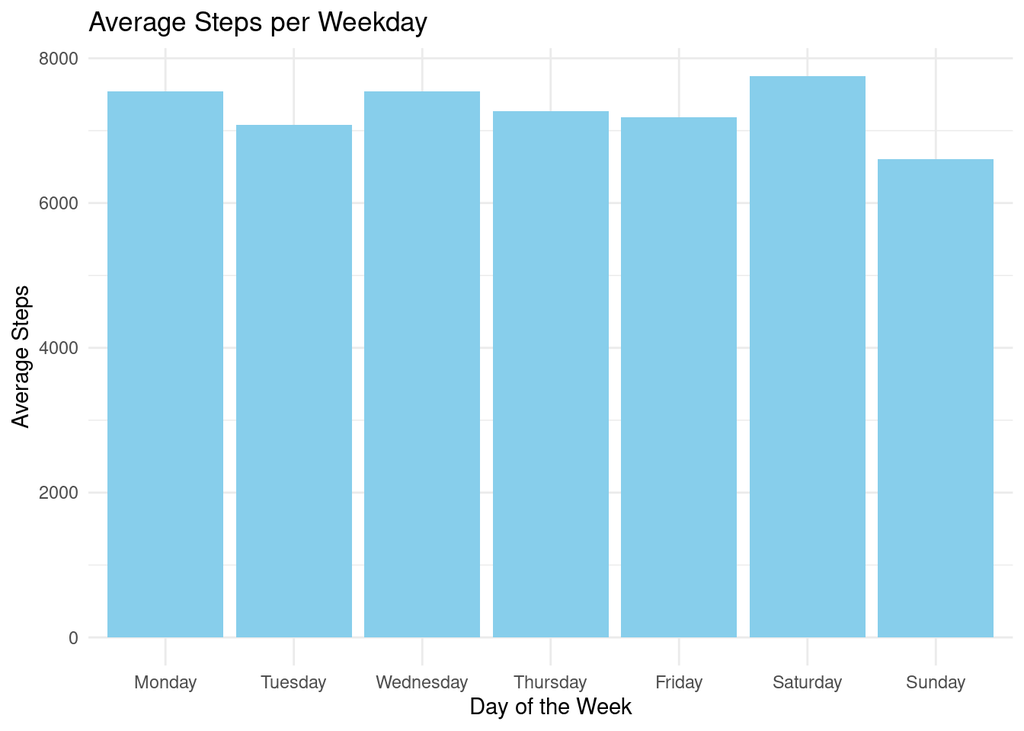

```r
avg_steps_by_day <- act_merged %>%
  group_by(day_of_week) %>%
  summarise(avg_steps = mean(TotalSteps, na.rm = TRUE)) %>%
  ungroup()

avg_steps_by_day$day_of_week<-factor(avg_steps_by_day$day_of_week, levels
  = c("Monday","Tuesday","Wednesday","Thursday","Friday", "Saturday", "Sunday"))

ggplot(data=avg_steps_by_day, aes(x = day_of_week, y = avg_steps)) +
  geom_col(fill = "skyblue") +
  labs(title = "Average Steps per Weekday", x = "Day of the Week", y = "Average Steps")+
  theme_minimal()
```

This allowed me to see the average steps per day of the week through columns. Unlike the total number, it instead showed that **on average, Mondays, Wednesdays, and Saturdays were the largest step days** with Sunday having the lowest, on average.

It was an interesting distinction compared to looking at the outliers.

While I was processing that information, I decided to dive deeper into activity level and steps using the raw information.

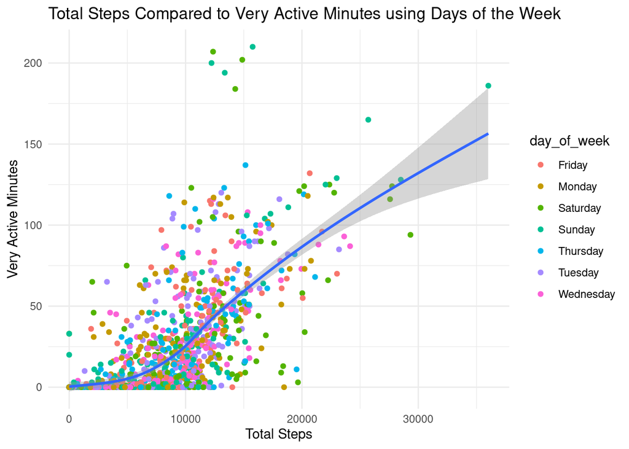

```r
ggplot(data=act_merged)+
  geom_point(mapping=aes(x=TotalSteps, y=VeryActiveMinutes, color=day_of_week))+
  geom_smooth(mapping=aes(x=TotalSteps, y=VeryActiveMinutes))+
  labs(
    title = "Total Steps Compared to Very Active Minutes using Days of the Week",
    x= "Total Steps",
    y = "Very Active Minutes"
  )+
  theme_minimal()
```

Taking a look at the chart, we could see that typically, as people were more active, then they were more likely to take a lot of steps. Again, this was an assumption I already had, but the visualization helped.

This information implied that there needed to be ways to keep people active so that they could gain more steps while using the product. This usage would then build more trust in the usage.

Next I needed to categorize the users into **Above Average, Average, and Below Average** to better understand the average user habits for this small sample size.

- Above Average was *over 10,000* on average.
- Average was *7,000 to 10,000* (7000 being 1 above the median) on average and this article said, “Approximately 7000 steps per day was associated with risk reductions for all outcomes examined and might serve as a practical quantitative public health target.”
- Below Average was *below 7,000* steps on average.

```r
user_steps <- act_merged %>% #pipe designed to create user_steps
  group_by(Id) %>% #which I then group by Id
  summarise(avg_steps = mean(TotalSteps, na.rm = TRUE)) #and then find the average
user_steps #checking to make sure it worked
```

| Id | avg_steps |
| --- | --- |
| 1503960366 | 11935.780 |
| 1624580081 | 5167.200 |
| 1644430081 | 7780.925 |
| 1844505072 | 2876.023 |
| 1927972279 | 1269.070 |
| 2022484408 | 11595.093 |
| 2026352035 | 4960.140 |
| 2320127002 | 4276.372 |
| 2347167796 | 9647.121 |
| 2873212765 | 7299.256 |

[output cut: 25 more lines]

```r
user_steps <- user_steps %>%
  mutate(step_category = case_when(
    avg_steps < 7000 ~ "Below Average",
    # insufficient according to data and at the median or below
    avg_steps >= 7000 & avg_steps <= 10000 ~ "Average",
    # meets minimum set by 1 above the median
    avg_steps > 10000 ~ "Above Average"))
# exceeds recommended minimum
```

This allowed me to set things up to continue working. I wanted to see how many minutes per user were spent sedentary next.

**Note:** Sedentary time could be due to time not using the device or it could mean time they were working in an office or time they were traveling.

```r
user_sedentary <- act_merged %>%
  # Average sedentary minutes per user
  group_by(Id) %>%
  summarise(avg_sedentary = mean(SedentaryMinutes, na.rm = TRUE))

# Merge with step categories to better compare the two
user_analysis <- user_steps %>%
  left_join(user_sedentary, by = "Id")

# Needed to compare sedentary time across groups to see how they compare
sed_summary <- user_analysis %>%
  group_by(step_category) %>%
  summarise(mean_sedentary = mean(avg_sedentary, na.rm = TRUE),
            sd_sedentary = sd(avg_sedentary, na.rm = TRUE),
            n = n())

print(sed_summary)
```

```
## # A tibble: 3 × 4
##   step_category mean_sedentary sd_sedentary     n
##   <chr>                  <dbl>        <dbl> <int>
## 1 Above Average           937.         204.     7
## 2 Average                 853.         175.    12
## 3 Below Average          1148.         176.    16
```

The summary showed me that some strayed from the mean in each of the categories. Most people who were above average in terms of steps had a higher standard deviation when it came to sendentary behavior compared to those who were average and below average (which was interesting). This implied that to better improve a product, there was a continued need to improve consistency among users.

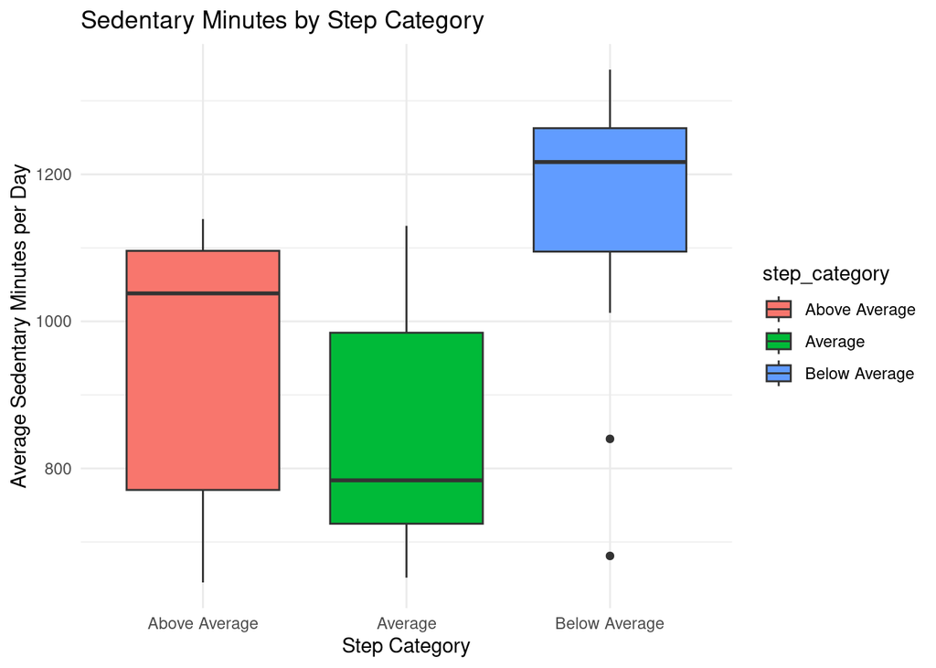

```r
# visualization using a boxplot
ggplot(user_analysis, aes(x = step_category, y = avg_sedentary, fill = step_category)) +
  geom_boxplot() +
  labs(title = "Sedentary Minutes by Step Category",
       x = "Step Category", y = "Average Sedentary Minutes per Day")+
  theme_minimal()
```

The box plot shows the distribution of sedentary minutes by step category for the users. The line in each box indicated the median sedentary time, while the box itself represents the middle 50% of values. Longer boxes or wider spread indicated more variation in sedentary behavior among users while shorter boxes meant less variation in sedentary behavior.

It helped me see what I was viewing with the chart. Those who were below average steppers also had more sedentary time. However, they were also the group with the most outliers. Finding a way to get them to move into the higher tiers of step categories would contnue to build trust with the product. It was something to consider as I continued with my analysis.

Now to check the Standard Deviation to better understand how much total steps strayed from the average.

```r
consistency <- act_merged %>%
  group_by(Id) %>%
  summarise(step_sd = sd(TotalSteps, na.rm = TRUE),
            avg_steps = mean(TotalSteps, na.rm = TRUE))
tibble(consistency) #to check if it worked.
```

| Id | step_sd | avg_steps |
| --- | --- | --- |
| 1503960366 | 3135.565 | 11935.780 |
| 1624580081 | 5574.154 | 5167.200 |
| 1644430081 | 4697.155 | 7780.925 |
| 1844505072 | 2764.522 | 2876.023 |
| 1927972279 | 1435.044 | 1269.070 |
| 2022484408 | 3105.767 | 11595.093 |
| 2026352035 | 2839.500 | 4960.140 |
| 2320127002 | 2688.554 | 4276.372 |
| 2347167796 | 4186.767 | 9647.121 |
| 2873212765 | 2453.857 | 7299.256 |

[output cut: 25 more lines]

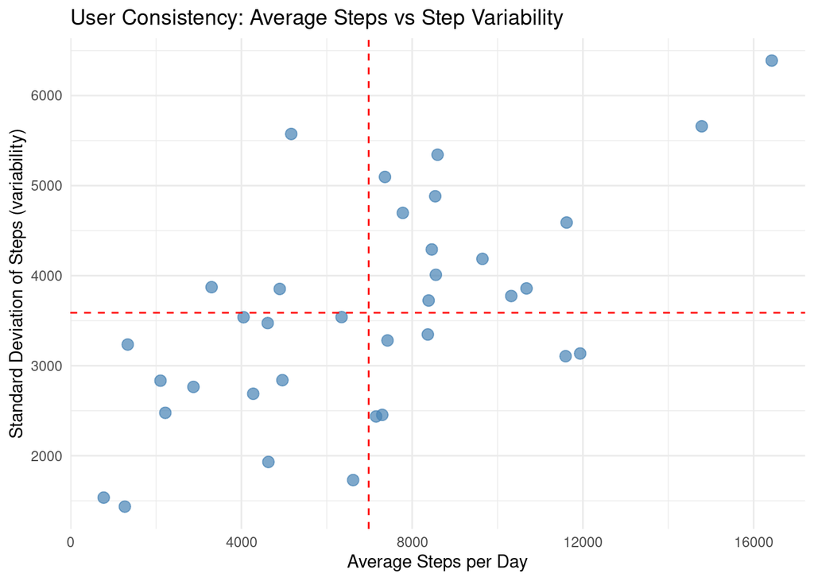

```r
ggplot(consistency, aes(x = avg_steps, y = step_sd)) +
  geom_point(color = "steelblue", size = 3, alpha = 0.7) +
  geom_hline(yintercept = mean(consistency$step_sd), linetype = "dashed", color = "red") +
  geom_vline(xintercept = mean(consistency$avg_steps), linetype = "dashed", color = "red") +
  labs(
    title = "User Consistency: Average Steps vs Step Variability",
    x = "Average Steps per Day",
    y = "Standard Deviation of Steps (variability)"
  ) +
  theme_minimal()
```

This visual gave me an understanding out how many users were consistent v how many were inconsistent.

The bottom showed consistency with steps and step counts while the top showed inconsistency. The left showed low step count while the right showed high step count.

Combined, the bottom-right showed high step count users and low standard deviation meaning they were consistently getting high steps, but they were not the majority.

Additionally, since there were people who did not have a full set of data in the time-frame, implying that they did not wear the Fitbit all the time for whatever reason, it would add to them being an inconsistent user of the watch, not just someone who takes fewer steps. This would imply that there needs to be a way for users to feel inclined to use it daily in some way.

Since, users fell into four groups: consistently high active, consistently low active, inconsistent high active, inconsistent low active and most users fell into inconsistent or low categories, this suggested that Bellabeat could focus on habit-building nudges.

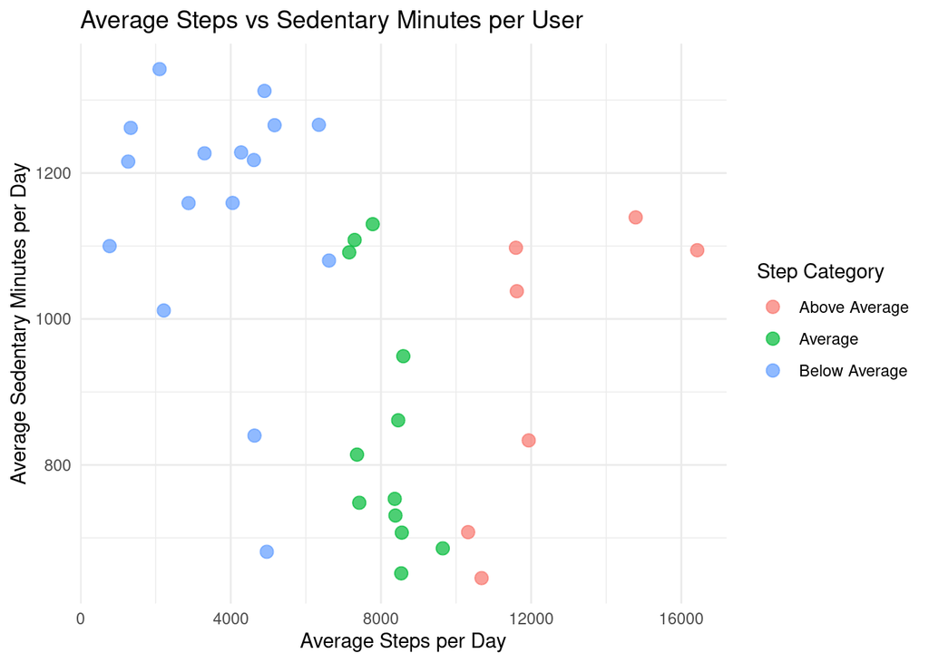

```r
ggplot(data=user_analysis, aes(x = avg_steps, y = avg_sedentary, color = step_category)) +
  geom_point(size = 3, alpha = 0.7) +
  labs(
    title = "Average Steps vs Sedentary Minutes per User",
    x = "Average Steps per Day",
    y = "Average Sedentary Minutes per Day",
    color = "Step Category"
  ) +
  theme_minimal()
```

```r
cor(user_analysis$avg_steps, user_analysis$avg_sedentary, use = "complete.obs")
```

```
## [1] -0.4142664
```

The scatterplot showed that as people took more steps, their amount of sedetary minutes went down. When I looked into the corelation, I got -0.4142664. The negative sign means that they have a negative relationship (one going up means the other goes down) which was what I suspected from the scatterplot.

So, I could not concretely say that more steps meant less sedentary time, but it seemed to indicate a downward trend. Right now, the weak correlation could be because of the device not being worn and those days counting as sedentary time. With more data, it could have been possible to gleam more. Either way, it further adds that users could benefit from incentives to staying active.

With all the data I had, I felt as though I was ready to move onto the recommendations. The primary theme I saw was a need for increased consistency with using the watch and remaining active.

# 5.RECOMMENDATIONS

#### Additional Thoughts

**Social Impact Potential in Marketing:** Though the data did not include demographic information, upon looking at the Bellabeat site, I noticed that they frequently used the word “women” as that is their target audience. However, if they expanded it to be more inclusive with language like “people who have periods” or “people seeking wholistic wellness,” it would open up the potential of a larger audience. Not all women have periods, so they may not be interested in those features. Specifically, women who have gone through menopause, women who have other health conditions that stopped their periods, and trans women do not have periods. But, there are trans men and non binary people who do still have periods. With the small change to inclusive language, it has the potential to increase the potential customer base while also appealing to inclusivity and visibility.